# Final Project: Examining the Relationship Between Demographics, Admission Types, and Clinical Outcomes in New York Inpatients (Niagara County)

Team 2: Simintaj Salehpour,Madeline Bumpus, Nazish Atta, Divya Mistry

December 09, 2025

# 1 Introduction

Our team chose to examine differences in **hospital length of stay (LOS)** across **insurance types** because it highlights an important intersection between healthcare access, cost, and patient outcomes. The relationship between insurance coverage and hospital utilization is central to understanding disparities in care delivery and efficiency within the U.S. healthcare system. We were particularly interested in comparing **Medicare**, which primarily serves older adults, and **Private Insurance**, which often provides broader access to care, to see how coverage type influences hospital resource use. Members of our team who have personally dealt with **Medicaid** and have seen firsthand how insurance status can impact the quality, timing, and length of medical care also find personal significance in this topic. We sought to better understand how insurance differences translate into quantifiable healthcare outcomes by combining our personal viewpoints with data-driven evidence through the analysis of actual hospital discharge data.

# 2 Data Description

## 2.1 Datasets used

This analysis uses data from the **New York State Department of Health (NYSDOH) Statewide Planning and Research Cooperative System (SPARCS)**, specifically the *Hospital Inpatient Discharges (SPARCS De-Identified)* dataset for **Niagara County, 2024**. The dataset includes detailed records of all hospital discharges statewide, with variables describing patient demographics, diagnoses, procedures, hospital facility characteristics, insurance/payment type, admission type, and clinical outcomes. Each row represents one patient discharge, allowing for analysis of trends in hospital length of stay, cost, and patient mix. The full dataset contains over **2 million records** across New York State; for this project, a subset of approximately **6,913 discharges from Niagara County** was used to maintain manageability and statistical power. This dataset is publicly available through the **NY Open Data Portal** and is widely used in healthcare policy, public health, and data science research.

```r
# Load CSV file
data <- read.csv("Hospital_Inpatient_Discharges_2024.csv")

#Clean column names to avoid backticks

names(data) <- make.names(names(data))

cat("Dataset dimensions: Rows:", nrow(data), "Columns:", ncol(data), "\n")
```

```
## Dataset dimensions: Rows: 6912 Columns: 33
```

```r
#glimpse(data)
```

## 2.2 Missing data

- Report missingness by variable: We check if there is a missing value or not. For each column check the missing value.

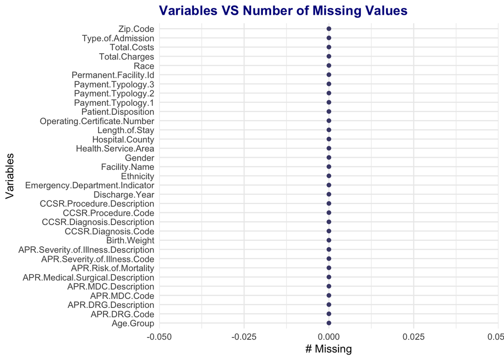

```r
# --- 1. Summary of missing values ---
missing_summary <- data %>% summarise(across(everything(), ~sum(is.na(.)))) %>%
  pivot_longer(everything(), names_to = "column(variable)", values_to = "n_missing") %>% arrange(desc(n_missing))

#missing_summary

# --- 2. Visualize missingness per column ---
gg_miss_var(data) + labs(title = "Variables VS Number of Missing Values") +
  theme( plot.title = element_text(face = "bold", color = "darkblue"))
```

```r
# --- 3. Check if there are any missing values ---
clean_data <- data
if(any(is.na(data))) {

  cat("Missing values detected!\n")
  total_missing <- sum(is.na(data))
  total_cells <- nrow(data) * ncol(data)

  # Remove rows if missing values are few (<5% of total data)
  if(total_missing / total_cells < 0.05) {
    clean_data <- na.omit(data)
    cat("Rows with missing values removed.\n")
  }
  else {
    # Impute numeric columns with median
    for(col in names(clean_data)) {
      if(is.numeric(clean_data[[col]])) {          # Check if the column is numeric
          clean_data[[col]][is.na(clean_data[[col]])] <- median(clean_data[[col]], na.rm = TRUE)
      }
    }
    cat("Missing values in numeric columns replaced with median.\n")
  }

} else {
  cat("No missing values detected. Dataset is clean.\n")
}
```

```
## No missing values detected. Dataset is clean.
```

## 2.3 Remove Duplicates

- Report Duplicates by row: Check to remove duplicates:

```r
dup_count <- sum(duplicated(clean_data))
cat("Number of duplicate rows:", dup_count, "\n")
```

```
## Number of duplicate rows: 1
```

```r
# Remove duplicates
clean_data <- clean_data %>% distinct()
```

# 3 SMART Questions

The team developed the following **SMART research questions** based on data availability, clinical reasoning, and literature review. These focus on measurable outcomes—length of stay and costs—to analyze healthcare disparities.

1. What factors significantly increase the likelihood of a longer hospital stay (>3 days)?
2. What combination of patient demographics, admission type, and comorbidities predicts the lowest hospital charges for Medicaid vs. Private Insurance patients in 2024?
3. Which combination of patient age group, severity of illness, and payer type predicts the lowest hospital readmission risk?
4. Which factors predict in-hospital mortality, and how accurately can we classify high-risk patients?

## 3.1 SMART Question 1

**What factors significantly increase the likelihood of a long hospital stay (>3 days)?**

We selected logistic regression because our outcome (whether a patient stayed longer than 3 days) was a binary classification problem. Logistic regression provides interpretable coefficients and odds ratios, which allow us to identify which factors significantly increase the likelihood of a long stay. We also used a random forest classifier as a complementary, non-linear model to check whether more complex interactions or variable importance patterns supported the regression findings. Logistic regression offered better interpretability, while random forest helped validate which predictors mattered most.

```r
# What factors increase long LOS (>3 days)?

library(dplyr)
library(caret)
library(broom)
library(ggplot2)
library(randomForest)

# 1. Use the cleaned data

df <- clean_data %>%
  # Create binary outcome
  mutate(
    LongStay = ifelse(Length.of.Stay > 3, 1, 0),

    # Insurance grouping
    Insurance_Group = case_when(
      Payment.Typology.1 == "Medicare" |
        Payment.Typology.2 == "Medicare" |
        Payment.Typology.3 == "Medicare" ~ "Medicare",

      Payment.Typology.1 == "Medicaid" |
        Payment.Typology.2 == "Medicaid" |
        Payment.Typology.3 == "Medicaid" ~ "Medicaid",

      Payment.Typology.1 %in% c("Blue Cross/Blue Shield", "Private Health Insurance") |
        Payment.Typology.2 %in% c("Blue Cross/Blue Shield", "Private Health Insurance") |
        Payment.Typology.3 %in% c("Blue Cross/Blue Shield", "Private Health Insurance") ~ "Private Insurance",

      TRUE ~ "Other"
    ),

    # Convert variables to factors
    LongStay = factor(LongStay, levels = c(0,1), labels = c("Short","Long")),
    Insurance_Group = factor(Insurance_Group),
    Age.Group = factor(Age.Group),
    Type.of.Admission = factor(Type.of.Admission),
    APR.Severity.of.Illness.Code = factor(APR.Severity.of.Illness.Code),
    Gender = factor(Gender)
  ) %>%
  select(LongStay, Insurance_Group, Age.Group, Type.of.Admission,
         APR.Severity.of.Illness.Code, Gender) %>%
  na.omit()

cat("Final modeling dataset rows:", nrow(df), "\n")
```

```
## Final modeling dataset rows: 6911
```

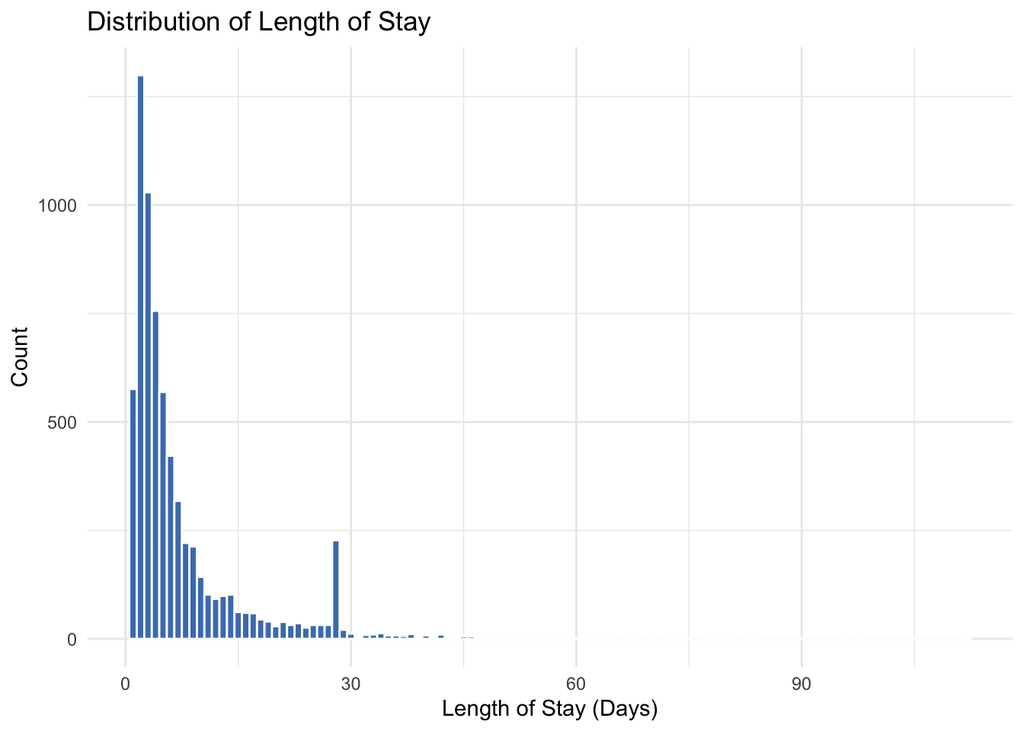

```r
# Remove rows with 'Not Available' admission type to avoid new levels in test set
df <- df %>% filter(Type.of.Admission != "Not Available")

# Make sure Length.of.Stay is numeric
clean_data <- clean_data %>%
  mutate(Length.of.Stay = as.numeric(Length.of.Stay))
# Check distribution of Length of Stay
ggplot(clean_data, aes(x = Length.of.Stay)) +
  geom_histogram(binwidth = 1, fill = "#4a7ebb", color = "white") +
  labs(title = "Distribution of Length of Stay",
       x = "Length of Stay (Days)",
       y = "Count")
```

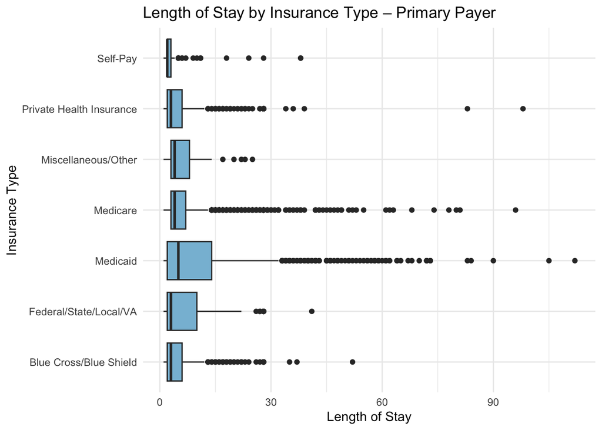

```r
# Boxplot of LOS by Insurance Type (raw, pre-filter)
ggplot(clean_data, aes(x = Payment.Typology.1, y = Length.of.Stay)) +
  geom_boxplot(fill = "#87bdd8") +
  coord_flip() +
  labs(title = "Length of Stay by Insurance Type – Primary Payer",
       x = "Insurance Type",
       y = "Length of Stay")
```

```r
# Check counts by insurance grouping
clean_data %>%
  count(Payment.Typology.1) %>%
  arrange(desc(n)) %>%
  kable(caption = "Counts of Insurance Types (Primary Payer)") %>%
  kable_styling(full_width = FALSE)
```

Counts of Insurance Types (Primary Payer)

| Payment.Typology.1 | n |
| --- | --- |
| Medicare | 3616 |
| Medicaid | 2179 |
| Private Health Insurance | 510 |
| Blue Cross/Blue Shield | 318 |
| Self-Pay | 123 |
| Federal/State/Local/VA | 112 |
| Miscellaneous/Other | 53 |

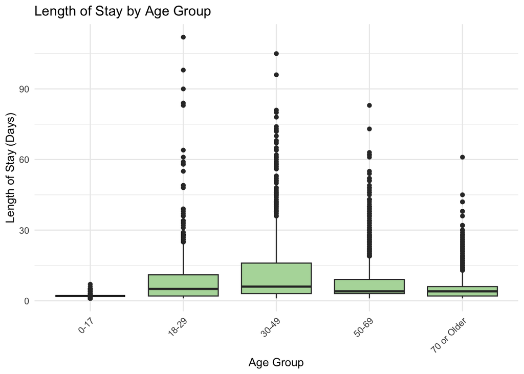

```r
# LOS by Patient Age Group
ggplot(clean_data, aes(x = Age.Group, y = Length.of.Stay)) +
  geom_boxplot(fill = "#b3d9a8") +
  labs(title = "Length of Stay by Age Group",
       x = "Age Group",
       y = "Length of Stay (Days)") +
  theme(axis.text.x = element_text(angle = 45, hjust = 1))
```

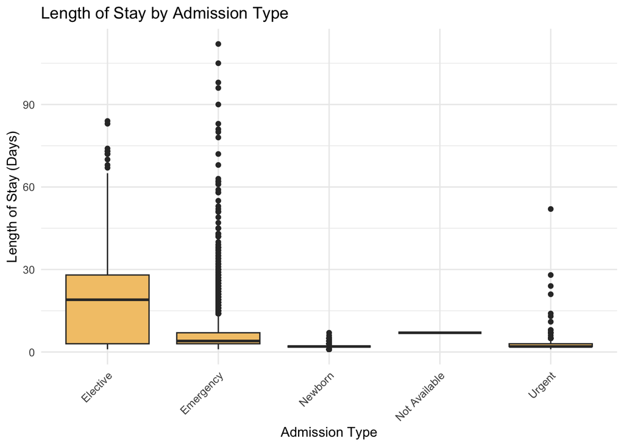

```r
# LOS by Type of Admission
ggplot(clean_data, aes(x = Type.of.Admission, y = Length.of.Stay)) +
  geom_boxplot(fill = "#f3c677") +
  labs(title = "Length of Stay by Admission Type",
       x = "Admission Type",
       y = "Length of Stay (Days)") +
  theme(axis.text.x = element_text(angle = 45, hjust = 1))
```

```r
# Crosstab: proportion of long stays by admission type
clean_data %>%
  mutate(LongStay = ifelse(Length.of.Stay > 3, "Long", "Short")) %>%
  count(Type.of.Admission, LongStay) %>%
  group_by(Type.of.Admission) %>%
  mutate(prop = n/sum(n)) %>%
  kable(caption = "Proportion of Long vs Short Stays by Admission Type") %>%
  kable_styling(full_width = FALSE)
```

Proportion of Long vs Short Stays by Admission Type

| Type.of.Admission | LongStay | n | prop |
| --- | --- | --- | --- |
| Elective | Long | 750 | 0.7492507 |
| Elective | Short | 251 | 0.2507493 |
| Emergency | Long | 3201 | 0.5923390 |
| Emergency | Short | 2202 | 0.4074759 |
| Emergency | NA | 1 | 0.0001850 |
| Newborn | Long | 19 | 0.0618893 |
| Newborn | Short | 288 | 0.9381107 |
| Not Available | Long | 1 | 1.0000000 |
| Urgent | Long | 35 | 0.1767677 |
| Urgent | Short | 163 | 0.8232323 |

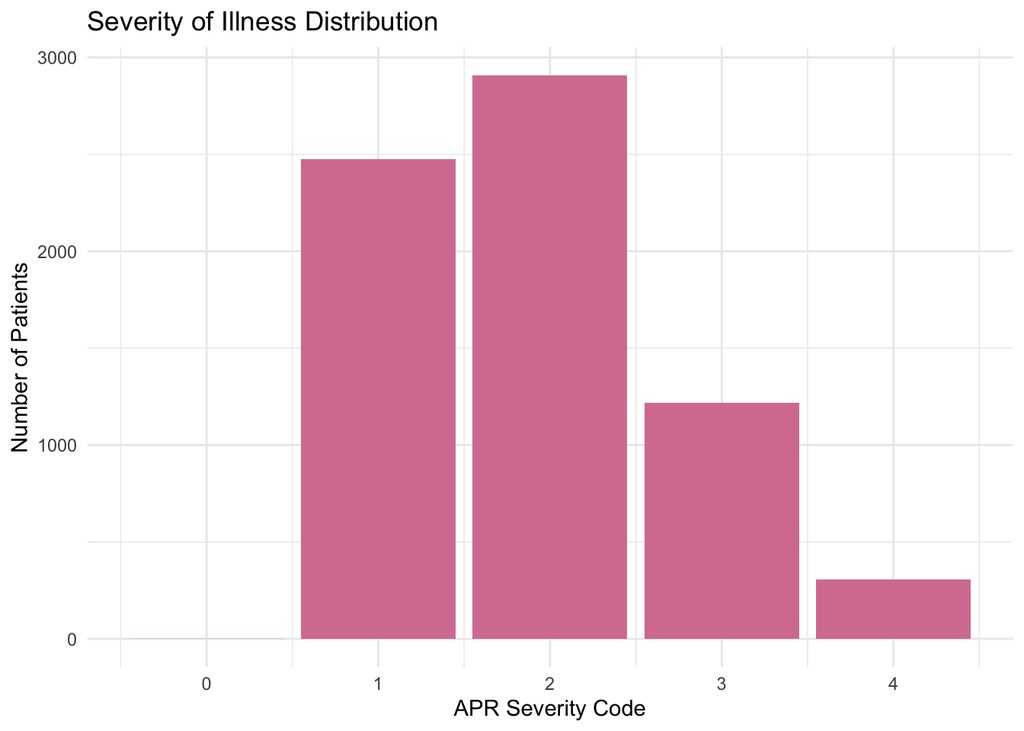

```r
# Checking severity distribution
ggplot(clean_data, aes(x = APR.Severity.of.Illness.Code)) +
  geom_bar(fill = "#d77fa1") +
  labs(title = "Severity of Illness Distribution",
       x = "APR Severity Code",
       y = "Number of Patients")
```

```r
# 2. Train/Test Split
set.seed(123)
index <- createDataPartition(df$LongStay, p = 0.8, list = FALSE)
train <- df[index, ]
test <- df[-index, ]

# 3. Logistic Regression Model
log_model <- glm(
  LongStay ~ Insurance_Group + Age.Group + Type.of.Admission +
    APR.Severity.of.Illness.Code + Gender,
  data = train,
  family = binomial
)

summary(log_model)
```

```
##
## Call:
## glm(formula = LongStay ~ Insurance_Group + Age.Group + Type.of.Admission +
##     APR.Severity.of.Illness.Code + Gender, family = binomial,
##     data = train)
##
## Coefficients:
##                                   Estimate Std. Error z value Pr(>|z|)
## (Intercept)                      -10.01342  196.96948  -0.051  0.95946
## Insurance_GroupMedicare           -0.16993    0.08888  -1.912  0.05588 .
## Insurance_GroupOther              -0.62047    0.18080  -3.432  0.00060 ***
## Insurance_GroupPrivate Insurance  -0.29941    0.10805  -2.771  0.00559 **
## Age.Group18-29                     0.56270    0.78435   0.717  0.47312
## Age.Group30-49                     0.65798    0.78229   0.841  0.40029
## Age.Group50-69                     0.68341    0.78399   0.872  0.38336
## Age.Group70 or Older               0.76015    0.78655   0.966  0.33383
## Type.of.AdmissionEmergency         0.70084    0.09128   7.678 1.62e-14 ***
## Type.of.AdmissionNewborn          -0.93216    0.82417  -1.131  0.25804
## Type.of.AdmissionUrgent           -0.61883    0.23691  -2.612  0.00900 **
## APR.Severity.of.Illness.Code1      8.37523  196.96792   0.043  0.96608
## APR.Severity.of.Illness.Code2      8.54091  196.96792   0.043  0.96541
## APR.Severity.of.Illness.Code3      8.61011  196.96793   0.044  0.96513
## APR.Severity.of.Illness.Code4      8.52009  196.96797   0.043  0.96550
## GenderM                            0.02451    0.05703   0.430  0.66733
## ---
## Signif. codes:  0 '***' 0.001 '**' 0.01 '*' 0.05 '.' 0.1 ' ' 1
##
## (Dispersion parameter for binomial family taken to be 1)
##
##     Null deviance: 7393.8  on 5528  degrees of freedom
## Residual deviance: 7092.3  on 5513  degrees of freedom
## AIC: 7124.3
##
## Number of Fisher Scoring iterations: 10
```

```r
# 4. Odds Ratios
odds <- tidy(log_model, exponentiate = TRUE, conf.int = TRUE)
kable(odds, caption = "Odds Ratios for Predictors of Long Hospital Stay")
```

Odds Ratios for Predictors of Long Hospital Stay

| term | estimate | std.error | statistic | p.value | conf.low | conf.high |
| --- | --- | --- | --- | --- | --- | --- |
| (Intercept) | 0.0000448 | 196.9694846 | -0.0508374 | 0.9594551 | NA | 1.110965e+13 |
| Insurance_GroupMedicare | 0.8437230 | 0.0888759 | -1.9120041 | 0.0558757 | 0.7086696 | 1.004103e+00 |
| Insurance_GroupOther | 0.5376911 | 0.1808040 | -3.4317332 | 0.0005997 | 0.3742269 | 7.613143e-01 |
| Insurance_GroupPrivate Insurance | 0.7412540 | 0.1080525 | -2.7709874 | 0.0055887 | 0.5989589 | 9.150056e-01 |
| Age.Group18-29 | 1.7554113 | 0.7843476 | 0.7174156 | 0.4731177 | 0.4556751 | 1.158375e+01 |
| Age.Group30-49 | 1.9308890 | 0.7822897 | 0.8410958 | 0.4002943 | 0.5036641 | 1.270757e+01 |
| Age.Group50-69 | 1.9806228 | 0.7839858 | 0.8717140 | 0.3833644 | 0.5144205 | 1.306252e+01 |
| Age.Group70 or Older | 2.1385944 | 0.7865475 | 0.9664373 | 0.3338254 | 0.5519464 | 1.415040e+01 |
| Type.of.AdmissionEmergency | 2.0154381 | 0.0912825 | 7.6776680 | 0.0000000 | 1.6875240 | 2.413836e+00 |
| Type.of.AdmissionNewborn | 0.3937012 | 0.8241738 | -1.1310273 | 0.2580436 | 0.0921997 | 2.733121e+00 |
| Type.of.AdmissionUrgent | 0.5385747 | 0.2369068 | -2.6121210 | 0.0089982 | 0.3319892 | 8.432854e-01 |
| APR.Severity.of.Illness.Code1 | 4338.2459391 | 196.9679186 | 0.0425208 | 0.9660836 | 0.0000000 | NA |
| APR.Severity.of.Illness.Code2 | 5120.0263401 | 196.9679224 | 0.0433620 | 0.9654130 | 0.0000000 | NA |
| APR.Severity.of.Illness.Code3 | 5486.8591768 | 196.9679310 | 0.0437133 | 0.9651330 | 0.0000000 | NA |
| APR.Severity.of.Illness.Code4 | 5014.5137315 | 196.9679654 | 0.0432562 | 0.9654973 | 0.0000000 | NA |
| GenderM | 1.0248144 | 0.0570273 | 0.4298214 | 0.6673256 | 0.9164338 | 1.146020e+00 |

```r
# 5. Model Evaluation
pred_prob <- predict(log_model, newdata = test, type = "response")
pred_class <- ifelse(pred_prob > 0.5, "Long", "Short") |> factor(levels = c("Short","Long"))

conf_mat <- confusionMatrix(pred_class, test$LongStay, positive = "Long")

print(conf_mat)
```

```
## Confusion Matrix and Statistics
##
##           Reference
## Prediction Short Long
##      Short   835  530
##      Long      8    8
##
##                Accuracy : 0.6104
##                  95% CI : (0.5841, 0.6363)
##     No Information Rate : 0.6104
##     P-Value [Acc > NIR] : 0.5118
##
##                   Kappa : 0.0065
##
##  Mcnemar's Test P-Value : <2e-16
##
##             Sensitivity : 0.014870
##             Specificity : 0.990510
##          Pos Pred Value : 0.500000
##          Neg Pred Value : 0.611722
##              Prevalence : 0.389573
##          Detection Rate : 0.005793
##    Detection Prevalence : 0.011586
##       Balanced Accuracy : 0.502690
##
##        'Positive' Class : Long
##
```

```r
cat("Model Accuracy:", round(conf_mat$overall["Accuracy"], 3), "\n")
```

```
## Model Accuracy: 0.61
```

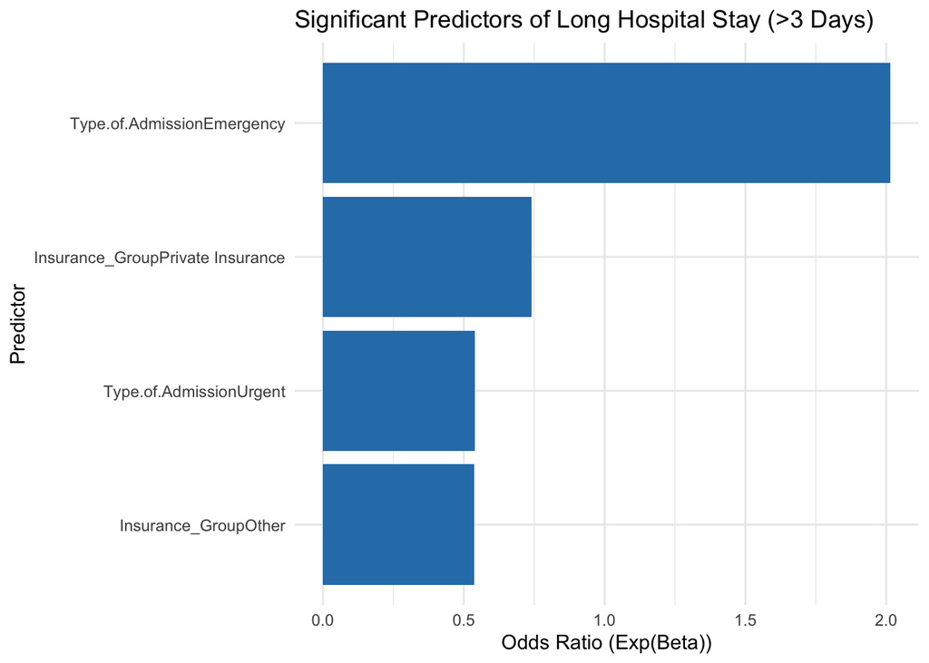

```r
# 6. Visualization of Significant Predictors
odds %>%
  filter(p.value < 0.05) %>%
  ggplot(aes(x = reorder(term, estimate), y = estimate)) +
  geom_col(fill = "#2c7fb8") +
  coord_flip() +
  labs(
    title = "Significant Predictors of Long Hospital Stay (>3 Days)",
    x = "Predictor",
    y = "Odds Ratio (Exp(Beta))"
  ) +
  theme_minimal()
```

```r
# 7. Random Forest model to predict LongStay

cat("\n--- Random Forest model ---\n")
```

```
##
## --- Random Forest model ---
```

```r
set.seed(123)
rf_fit <- randomForest(
  LongStay ~ .,
  data = train,
  ntree = 500,
  importance = TRUE
)

print(rf_fit)
```

```
##
## Call:
##  randomForest(formula = LongStay ~ ., data = train, ntree = 500,      importance = TRUE)
##                Type of random forest: classification
##                      Number of trees: 500
## No. of variables tried at each split: 2
##
##         OOB estimate of  error rate: 39.18%
## Confusion matrix:
##       Short Long class.error
## Short  3318   56  0.01659751
## Long   2110   45  0.97911833
```

```r
rf_pred <- predict(rf_fit, newdata = test)
rf_cm <- confusionMatrix(rf_pred, test$LongStay, positive = "Long")
print(rf_cm)
```

```
## Confusion Matrix and Statistics
##
##           Reference
## Prediction Short Long
##      Short   838  523
##      Long      5   15
##
##                Accuracy : 0.6177
##                  95% CI : (0.5914, 0.6434)
##     No Information Rate : 0.6104
##     P-Value [Acc > NIR] : 0.3006
##
##                   Kappa : 0.0266
##
##  Mcnemar's Test P-Value : <2e-16
##
##             Sensitivity : 0.02788
##             Specificity : 0.99407
##          Pos Pred Value : 0.75000
##          Neg Pred Value : 0.61572
##              Prevalence : 0.38957
##          Detection Rate : 0.01086
##    Detection Prevalence : 0.01448
##       Balanced Accuracy : 0.51097
##
##        'Positive' Class : Long
##
```

```r
cat("Random Forest Accuracy:", round(rf_cm$overall["Accuracy"], 3), "\n")
```

```
## Random Forest Accuracy: 0.618
```

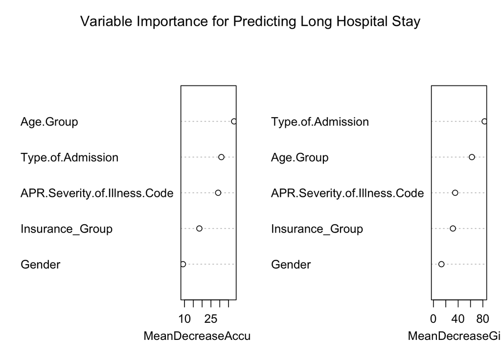

```r
# Variable importance plot
varImpPlot(rf_fit, main = "Variable Importance for Predicting Long Hospital Stay")
```

```r
# 8. ROC Curves & AUC Comparison

library(pROC)

cat("\n--- ROC Curve and AUC Comparison ---\n")
```

```
##
## --- ROC Curve and AUC Comparison ---
```

```r
# --- Logistic Regression ROC ---
logit_prob <- predict(log_model, newdata = test, type = "response")

roc_logit <- roc(
  response = test$LongStay,
  predictor = logit_prob,
  levels = c("Short", "Long"),
  direction = "<"
)

logit_auc <- auc(roc_logit)
cat("Logistic Regression AUC:", round(logit_auc, 3), "\n")
```

```
## Logistic Regression AUC: 0.618
```

```r
# --- Random Forest ROC ---
rf_prob <- predict(rf_fit, newdata = test, type = "prob")[, "Long"]

roc_rf <- roc(
  response = test$LongStay,
  predictor = rf_prob,
  levels = c("Short", "Long"),
  direction = "<"
)

rf_auc <- auc(roc_rf)
cat("Random Forest AUC:", round(rf_auc, 3), "\n")
```

```
## Random Forest AUC: 0.58
```

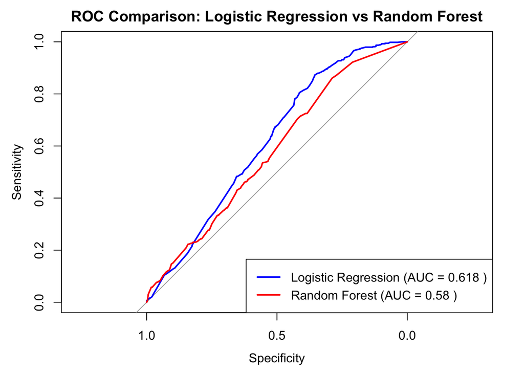

```r
# --- Plot both ROC curves ---
plot(
  roc_logit, col = "blue", lwd = 2,
  main = "ROC Comparison: Logistic Regression vs Random Forest"
)
plot(
  roc_rf, col = "red", lwd = 2, add = TRUE
)

legend(
  "bottomright",
  legend = c(
    paste("Logistic Regression (AUC =", round(logit_auc, 3), ")"),
    paste("Random Forest (AUC =", round(rf_auc, 3), ")")
  ),
  col = c("blue", "red"),
  lwd = 2
)
```

## 3.2 SMART Question 2

**What combination of patient demographics, admission type, and comorbidities predicts the lowest hospital charges for Medicaid vs. Private Insurance patients in 2024?**

```r
library(dplyr)
library(forcats)
library(ggplot2)
library(randomForest)

# Data cleaning
clean_data <- clean_data %>%
  mutate(
    Total.Charges = as.numeric(gsub("[^0-9\\.]", "", Total.Charges)),
    Length.of.Stay = as.numeric(as.character(Length.of.Stay))
  ) %>%
  filter(!is.na(Total.Charges), is.finite(Total.Charges), Total.Charges > 0)



# Filter Insurance types
medicaid_pattern <- "Medicaid|federal/state/local/va"
private_pattern  <- "Blue Cross/Blue Shield|Private Health Insurance|Miscellaneous/Other"

hospital_filtered <- clean_data %>%
  mutate(
    Insurance = case_when(
      if_any(starts_with("Payment.Typology"), ~ str_detect(., medicaid_pattern)) ~ "Medicaid",
      if_any(starts_with("Payment.Typology"), ~ str_detect(., private_pattern))  ~ "Private",
      TRUE ~ "Other"
    )
  ) %>%
  filter(Insurance %in% c("Medicaid", "Private"))


# Keep relevant columns
columns_to_keep <- c(
  "Age.Group", "Gender","Race", "Length.of.Stay","Type.of.Admission",
  "Emergency.Department.Indicator","APR.Medical.Surgical.Description",
  "APR.Severity.of.Illness.Description","APR.DRG.Code","CCSR.Diagnosis.Description",
  "Insurance","Total.Charges"
)
hospital_final <- hospital_filtered[, columns_to_keep]

# Convert low frequency levels to "Other" and handle NA
factors_to_fix <- c(
  "Age.Group","Gender","Race","Type.of.Admission",
  "Emergency.Department.Indicator","APR.Severity.of.Illness.Description","CCSR.Diagnosis.Description")

for(f in factors_to_fix){
  hospital_final[[f]] <- fct_lump_min(as.factor(hospital_final[[f]]), min = 20, other_level = "Other")
  hospital_final[[f]] <- fct_explicit_na(hospital_final[[f]], na_level = "Other")
}
cat("After labling Insurances as Medicaid and Private and remove other kinds like Medicare and self-payment \nStructure of final filtered dataset with demographics, admission type, and comorbidities variables to predicts the lowest hospital charges for Medicaid vs. Private Insurance: ")
```

```
## After labling Insurances as Medicaid and Private and remove other kinds like Medicare and self-payment
## Structure of final filtered dataset with demographics, admission type, and comorbidities variables to predicts the lowest hospital charges for Medicaid vs. Private Insurance:
```

```r
glimpse(hospital_final)
```

```
## Rows: 4,650
## Columns: 12
## $ Age.Group                           <fct> 50-69, 30-49, 50-69, 0-17, 30-49, …
## $ Gender                              <fct> M, F, F, F, F, F, M, F, F, F, F, F…
## $ Race                                <fct> White, Black/African American, Bla…
## $ Length.of.Stay                      <dbl> 3, 4, 1, 2, 6, 11, 2, 3, 5, 4, 2, …
## $ Type.of.Admission                   <fct> Emergency, Emergency, Emergency, N…
## $ Emergency.Department.Indicator      <fct> Y, Y, N, N, Y, Y, N, N, Y, Y, N, N…
## $ APR.Medical.Surgical.Description    <chr> "Medical", "Medical", "Surgical", …
## $ APR.Severity.of.Illness.Description <fct> Minor, Minor, Minor, Minor, Minor,…
## $ APR.DRG.Code                        <int> 243, 282, 320, 640, 751, 720, 174,…
## $ CCSR.Diagnosis.Description          <fct> "Other", "PANCREATIC DISORDERS (EX…
## $ Insurance                           <chr> "Medicaid", "Medicaid", "Medicaid"…
## $ Total.Charges                       <dbl> 10882.09, 12590.04, 11383.38, 4114…
```

```r
# Remove rows with any NA in predictors
predictors <- c(
  "Age.Group","Gender","Race","Type.of.Admission","Length.of.Stay",
  "Emergency.Department.Indicator","APR.Severity.of.Illness.Description","CCSR.Diagnosis.Description")
hospital_final <- hospital_final %>% filter(!if_any(all_of(predictors), is.na))


# Train/test split function with safe factor alignment
split_train_test <- function(df, train_ratio = 0.8) {
  set.seed(123)
  n <- nrow(df)
  train_idx <- sample(1:n, size = floor(train_ratio * n))
  train <- df[train_idx, ]
  test  <- df[-train_idx, ]

  for(f in names(train)[sapply(train, is.factor)]) {
    test[[f]] <- factor(test[[f]], levels = levels(train[[f]]))
    test[[f]] <- fct_explicit_na(test[[f]], na_level = "Other")
  }

  list(train = train, test = test)
}

# Split by Insurance
Medicaid_df <- hospital_final %>% filter(Insurance == "Medicaid")
Private_df  <- hospital_final %>% filter(Insurance == "Private")

medicaid_split <- split_train_test(Medicaid_df)
private_split  <- split_train_test(Private_df)

medicaid_split$train$logCharges <- log(medicaid_split$train$Total.Charges + 1)
medicaid_split$test$logCharges  <- log(medicaid_split$test$Total.Charges + 1)

private_split$train$logCharges <- log(private_split$train$Total.Charges + 1)
private_split$test$logCharges  <- log(private_split$test$Total.Charges + 1)
# Random Forest models

set.seed(123)
rf_medicaid <- randomForest(
  logCharges  ~ Age.Group + Gender + Race +
    Type.of.Admission + Length.of.Stay +
    Emergency.Department.Indicator +
    APR.Severity.of.Illness.Description +
    CCSR.Diagnosis.Description,
  data = medicaid_split$train,
  ntree = 500,
  mtry = 3,
  importance = TRUE
)
rf_medicaid
```

```
##
## Call:
##  randomForest(formula = logCharges ~ Age.Group + Gender + Race +      Type.of.Admission + Length.of.Stay + Emergency.Department.Indicator +      APR.Severity.of.Illness.Description + CCSR.Diagnosis.Description,      data = medicaid_split$train, ntree = 500, mtry = 3, importance = TRUE)
##                Type of random forest: regression
##                      Number of trees: 500
## No. of variables tried at each split: 3
##
##           Mean of squared residuals: 0.1065842
##                     % Var explained: 86.41
```

```r
# R² calculation
pred_log <- predict(rf_medicaid, medicaid_split$test)
real_log <- medicaid_split$test$logCharges
# R2 on log scale
# R2_log <- 1 - sum((pred_log - real_log)^2) / sum((real_log - mean(real_log))^2)
# cat("Medicaid:R2 (log scale):", R2_log, "\n")

# R2 on real scale
pred_real <- exp(pred_log) - 1
real_real <- medicaid_split$test$Total.Charges

R2_real <- 1 - sum((pred_real - real_real)^2) / sum((real_real - mean(real_real))^2)
cat("Medicaid: R2 (real scale):", R2_real, "\n")
```

```
## Medicaid: R2 (real scale): 0.799536
```

```r
rf_private <- randomForest(
  logCharges ~ Age.Group + Gender + Race +
    Type.of.Admission + Length.of.Stay +
    Emergency.Department.Indicator +
    APR.Severity.of.Illness.Description +
    CCSR.Diagnosis.Description,
  data = private_split$train,
  ntree = 500,
  mtry = 3,
  importance = TRUE
)
rf_private
```

```
##
## Call:
##  randomForest(formula = logCharges ~ Age.Group + Gender + Race +      Type.of.Admission + Length.of.Stay + Emergency.Department.Indicator +      APR.Severity.of.Illness.Description + CCSR.Diagnosis.Description,      data = private_split$train, ntree = 500, mtry = 3, importance = TRUE)
##                Type of random forest: regression
##                      Number of trees: 500
## No. of variables tried at each split: 3
##
##           Mean of squared residuals: 0.1605366
##                     % Var explained: 71.83
```

```r
# R² calculation
pred_log <- predict(rf_private, private_split$test)
real_log <- private_split$test$logCharges
# R2 on log scale
# R2_log <- 1 - sum((pred_log - real_log)^2) / sum((real_log - mean(real_log))^2)
# cat("Private:R2 (log scale):", R2_log, "\n")

# R2 on real scale
pred_real <- exp(pred_log) - 1
real_real <- private_split$test$Total.Charges

R2_real <- 1 - sum((pred_real - real_real)^2) / sum((real_real - mean(real_real))^2)
cat("Private: R2 (real scale):", R2_real, "\n")
```

```
## Private: R2 (real scale): 0.5393055
```

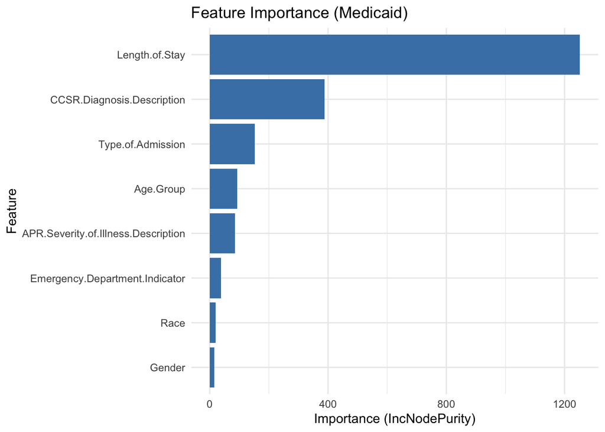

```r
top_features <- function(rf_model, n = 5){
  imp <- importance(rf_model)
  imp_df <- data.frame(
    Feature = rownames(imp),
    Importance = imp[, "IncNodePurity"]
  ) %>%
    arrange(desc(Importance))
  head(imp_df$Feature, n)
}

# Feature importance plots
plot_feature_importance <- function(rf_model, title = "Feature Importance") {
  imp <- importance(rf_model)
  imp_df <- data.frame(
    Feature = rownames(imp),
    Importance = imp[, "IncNodePurity"]
  ) %>% arrange(desc(Importance))

  ggplot(imp_df, aes(x = reorder(Feature, Importance), y = Importance)) +
    geom_col(fill = "steelblue") +
    coord_flip() +
    theme_minimal() +
    labs(title = title, x = "Feature", y = "Importance (IncNodePurity)")
}

# Medicaid
plot_feature_importance(rf_medicaid, title = "Feature Importance (Medicaid)")
```